# Bike Sharing useage by Casual Riders and Subscribers

Anorup Kanti Das

2025-08-26

Alright, this is my third attempt.In the first attempt, I tried cleaning the datasets in Excel and then analyze them in R. I was running into a lot of problems and wasted a lot of my time. In my second attempt, I did all the cleaning and analyzing only using R and was successfull. This is my third attempt. In this attempt, I plan on doing my complete process of analysis only using R but with a neat approach and more effective and readable codes. Let’s get started.

## About The Analysis

The goal for this analysis is to determine the usage difference of bike sharing by Cyclistic among Member & Casual, and find out if there is way Cyclistic can advertise to Casual customers to switch to becoming a Member becuase more profit comes from Members.

### About The Data

The data has been sourced from Cyclistic’s data warehouse. The data contains details about Bike Sharing usage in the last five quarters.

## Data visualizations with insights.

##### Skip to the **Key Findings** & **Reccomendations** part if not interested in graphs. The Key Finding Indicators or KPIs will be listed at the end.

##### It seems like the number of rides are mostly covered by subscribers on weekdays. Indicating commuting to work.

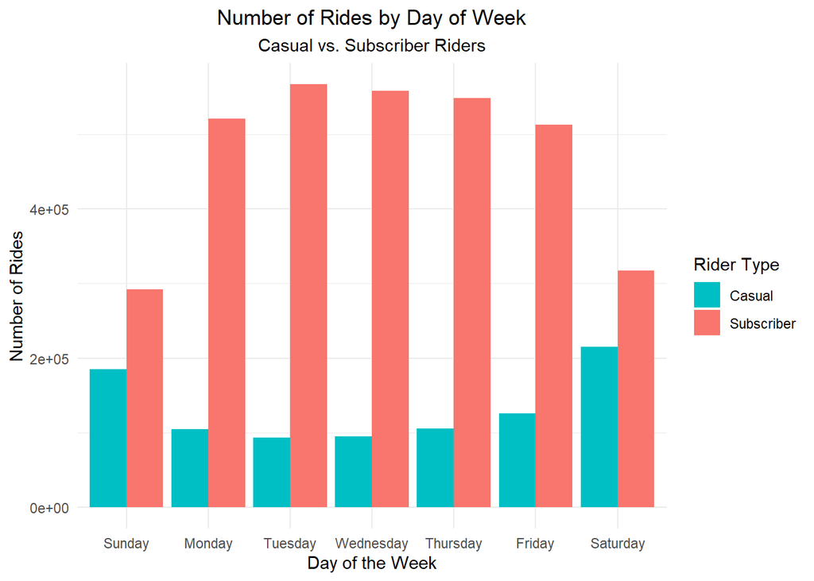

##### Interesting. Average Ride Duration is almost same everyday for Subscribers, and is very low. Again indicating commuting to work. On the other hand, Average Ride Duration for Casual Riders are long, indicating tourists or recreational riders.

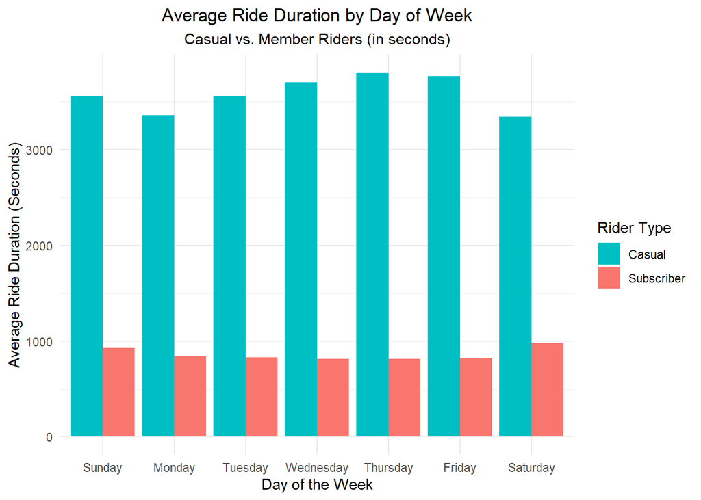

##### The density plots below shows the same insights as the previous graph chart. Indicating that more subscriber riders ride for less time and casual riders ride for longer.

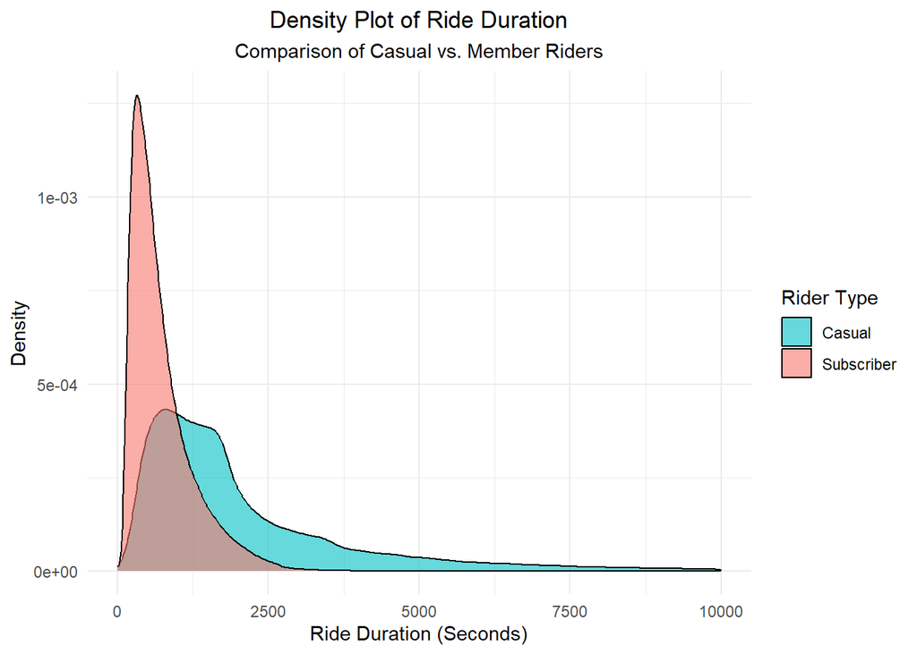

##### This plot shows that the number of rides increases in summer for both rider types and falls in winter.

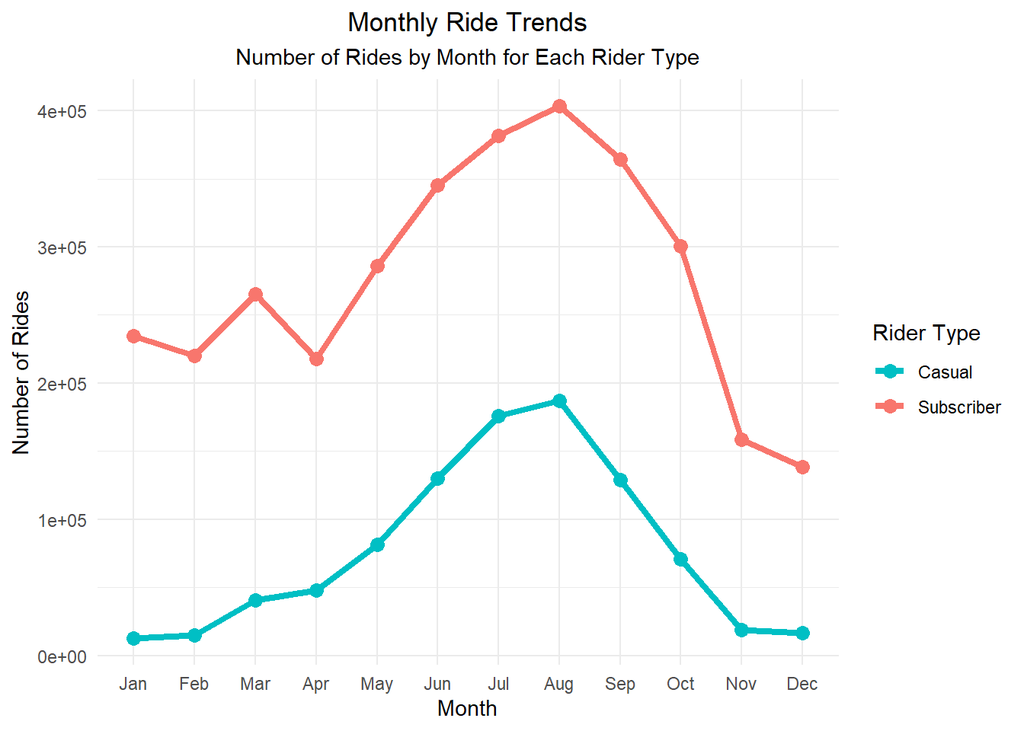

## Key Findings

- **Ride Frequency**: Members consistently make more rides than Casual users, especially on weekdays. This suggests members are largely commuters.
- **Ride Duration**: Casual riders take significantly longer trips than Members. This aligns with patterns of tourists and recreational riders.
- **Weekly Trends**: Casual usage spikes on weekends, while Member usage is higher during weekdays, again pointing to commuting behavior.
- **Ride Distribution**: The density plot shows Casual rides have a wider spread and heavier tail, confirming they sometimes take very long trips compared to Members.

## Business Insights

1. **Casual = Tourists / Leisure**
- Longer rides, weekend peaks.
- Likely renting bikes for sightseeing, group trips, or one-off leisure activities.
2. **Members = Commuters / Daily Users**
- Shorter, frequent weekday rides.
- Likely using bikes as part of their regular work commute.

## Recommendations

1. **Membership Conversions**
- Create targeted campaigns for Casual users offering “Weekend-to-Membership” discounts. Example: *“Save more when you ride regularly — convert to a Member today!”*
- Offer multi-day tourist passes that subtly encourage upgrading to full membership.
2. **Commuter Incentives**
- Partner with employers for corporate membership discounts.
- Highlight time savings and cost-effectiveness vs. other transport.
3. **Seasonality & Events**
- Launch seasonal promotions (summer = more tourists, winter = more locals).
- Target event-based traffic (festivals, conferences) with special deals.

### KPIs

```
##
##
## --- KEY PERFORMANCE INDICATORS (KPIs) ---
```

```
## # A tibble: 2 × 2
##   usertype   total_rides
##   <chr>            <int>
## 1 Casual          925345
## 2 Subscriber     3315766
```

```
## # A tibble: 2 × 2
##   usertype   average_ride
##   <chr>      <drtn>
## 1 Casual     3556.8495 secs
## 2 Subscriber  848.3654 secs
```

```
## # A tibble: 2 × 3
##   usertype   total_rides percentage
##   <chr>            <int>      <dbl>
## 1 Casual          925345       21.8
## 2 Subscriber     3315766       78.2
```

```
##
##  Welch Two Sample t-test
##
## data:  tripduration by usertype
## t = 43.637 secs, df = 958703, p-value < 2.2e-16
## alternative hypothesis: true difference in means between group Casual and group Subscriber is not equal to 0
## 95 percent confidence interval:
##  2586.831 secs 2830.137 secs
## sample estimates:
## Time differences in secs
##     mean in group Casual mean in group Subscriber
##                3556.8495                 848.3654
```